# Stat4214 Project Report

William Yao

2023-08-09

# Executive Summary

The project report delves into the realm of NBA player performance evaluation by investigating the influential factors behind Raptor ratings, which encapsulate a player’s contribution to team offense and defense. With a focus on the 2020 NBA season, the study seeks to unearth the pivotal attributes that significantly shape a player’s overall value within the league. The report’s research questions encompass diverse angles, including the exploration of correlations between Raptor ratings and player statistics, the identification of key performance metrics, the discovery of hidden indicators of importance, and the evaluation of the feasibility of predicting player value based on Raptor ratings and related attributes. The analysis spans data preparation, visualization, linear regression modeling, variable selection, assumption validation, and cross validation.

Through meticulous data analysis, the report spotlights assisting and blocking percentages as central determinants of Raptor ratings for the Atlanta Hawks during the 2020 season. These findings underscore the essential role of specific player attributes in shaping player performance outcomes, contributing insights into player valuation. While the study refines its scope to focus on a specific team and season, it offers a foundation framework for future exploration. Suggestions for further investigation include expanding the analysis across multiple seasons, investigating team dynamics, and enhancing model robustness through cross-validation techniques. Overall, the report provides a comprehensive exploration of the intricate interplay between player statistics and Raptor ratings, enriching our understanding of the factors that underpin player value within the dynamic landscape of professional basketball.

# Problem

## Problem Statement

The objective of this statistical report is to investigate the factors that significantly influence Raptor ratings in the context of NBA player performance. Raptor scores are numerical metrics that quantify a player’s contribution to both team offense and team defense per 100 possessions, relative to a league-average player. This study aims to understand the relationships between the overall Raptor rating and various player statistics, such as position, assist percent, turnover rate, rebound rate, steal percentage, blocking percentage, and age.

The motivation behind this analysis is to gain insights into the attributes that differentiate a valuable basketball player in the NBA. By comprehensively examining the impact of different player statistics on Raptor ratings, this study aims to shed light on what qualities contribute most significantly to a player’s overall performance. Furthermore, this research seeks to determine whether it is possible to predict a player’s value based on statistical metrics and identify which statistics are pivotal in defining a player’s significance to the league.

## Research Questions

1. To explore the correlation between Raptor ratings and various player statistics, including position, assist percent, turnover rate, rebound rate, steal percentage, blocking percentage, and minutes per game.
2. To identify which player statistics exhibit the strongest influence on Raptor ratings and contribute significantly to a player’s overall performance evaluation.
3. To uncover potential statistical indicators that may not strongly affect Raptor ratings but still hold importance in the broader context of basketball game play.
4. To assess the feasibility of predicting a player’s value to the NBA based on their performance statistics, particularly focusing on Raptor ratings and other relevant attributes.

# Data Analysis

I started by importing the necessary libraries.

```r
library(lmtest)
library(MASS)
library(readr)
```

I then imported and cleaned the data, to include only the 2020 season, as well as remove some of the more useless .

```r
#library(readr)
nba_data_historical <- read_csv("nba-data-historical.csv")
nba <- nba_data_historical[1:808,-c(8, 12, 14, 16:19, 24, 25, 34:39)]
```

## Ploting

I then plotted a scatter plot matrix in order to see if there was some correlation with some of the predictors. I noticed that some of the variables had a very low positive correlation with raptor scores such as stealing percentage and assisting percentage. I thought that the whole season of 2020 might be too much information and so I decided to increase the scope to focus on just the Atlanta Hawks to see if it would help in graphical clarification.

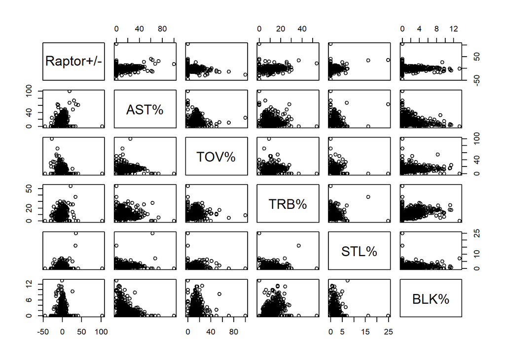

```r
pairs(nba[c("Raptor+/-", "AST%", "TOV%", "TRB%", "STL%", "BLK%")])
```

I cleaned the data to just include the Atlanta hawks basketball team, and then I created another scatter plot matrix. Less data points was very helpful in showing relationships between the variables.

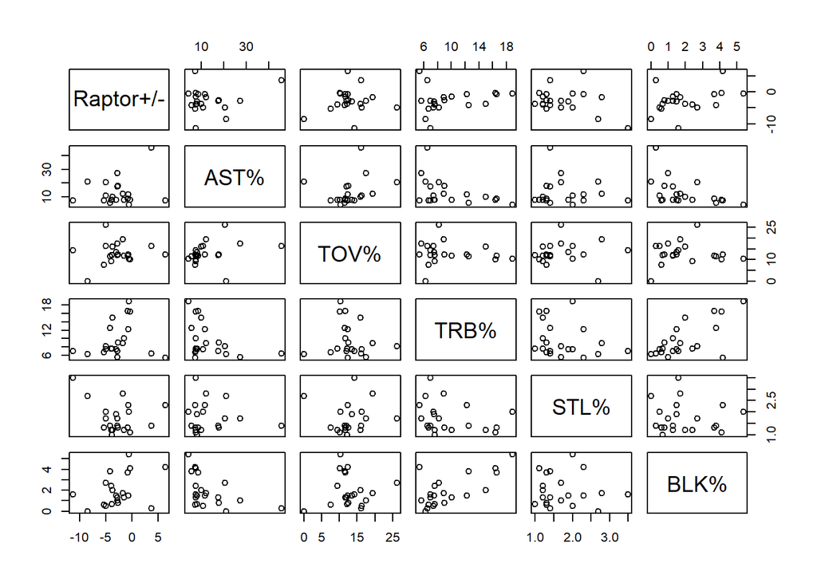

```r
nba_atl <- nba[1:21,]

pairs(nba_atl[c("Raptor+/-", "AST%", "TOV%", "TRB%", "STL%", "BLK%")])
```

```r
modatl <- lm(`Raptor+/-` ~ `AST%` + `TOV%` + `TRB%` + `STL%` + `BLK%`, data = nba_atl)
```

I then moved on to variable and model selection.

## Variable Selection

```r
# Perform forward selection
forward_model <- step(modatl, direction = "forward")
```

```
## Start:  AIC=55.03
## `Raptor+/-` ~ `AST%` + `TOV%` + `TRB%` + `STL%` + `BLK%`
```

```r
summary(forward_model$coefficients)
```

```
##    Min. 1st Qu.  Median    Mean 3rd Qu.    Max.
## -3.5031 -1.2989 -0.1066 -0.5702  0.1269  1.7867
```

```r
# Perform backward selection
backward_model <- step(modatl, direction = "backward")
```

```
## Start:  AIC=55.03
## `Raptor+/-` ~ `AST%` + `TOV%` + `TRB%` + `STL%` + `BLK%`
##
##          Df Sum of Sq    RSS    AIC
## - `TOV%`  1     0.132 163.11 53.048
## - `TRB%`  1     6.002 168.98 53.791
## <none>                162.98 55.031
## - `STL%`  1    21.836 184.82 55.672
## - `AST%`  1    37.760 200.74 57.407
## - `BLK%`  1    65.219 228.20 60.100
##
## Step:  AIC=53.05
## `Raptor+/-` ~ `AST%` + `TRB%` + `STL%` + `BLK%`
##
##          Df Sum of Sq    RSS    AIC
## - `TRB%`  1     5.880 168.99 51.792
## <none>                163.11 53.048
## - `STL%`  1    21.936 185.05 53.698
## - `AST%`  1    40.187 203.30 55.673
## - `BLK%`  1    67.327 230.44 58.305
##
## Step:  AIC=51.79
## `Raptor+/-` ~ `AST%` + `STL%` + `BLK%`
##
##          Df Sum of Sq    RSS    AIC
## <none>                168.99 51.792
## - `STL%`  1    17.253 186.25 51.833
## - `AST%`  1    45.791 214.78 54.827
## - `BLK%`  1    71.322 240.31 57.186
```

```r
summary(backward_model$coefficients)
```

```
##    Min. 1st Qu.  Median    Mean 3rd Qu.    Max.
## -5.4905 -2.4340 -0.6169 -1.3175  0.4996  1.4542
```

## Checking Assumptions

I first looked at the original model to see if all the assumptions were met. While independence, and normality were met, based on the histogram, the fitted vs residuals plot, and the Q-Q plot, constant Variance was not quite met as the B-P test had a p-value = 0.02427, which is very low, and not ideal.

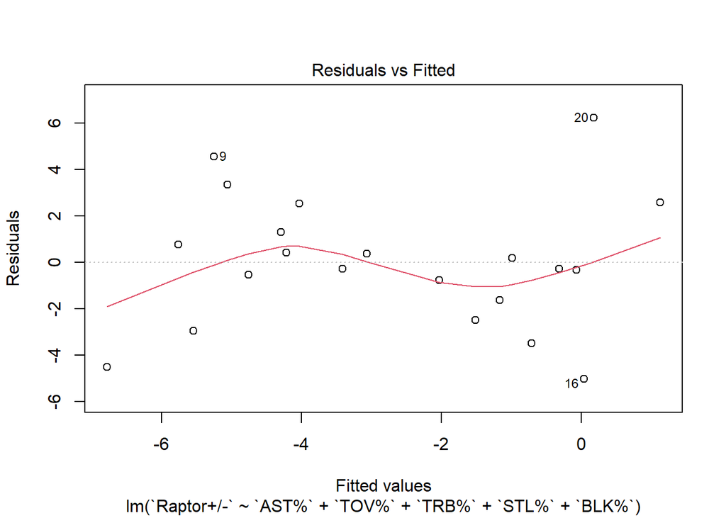

```r
plot(modatl,1)
```

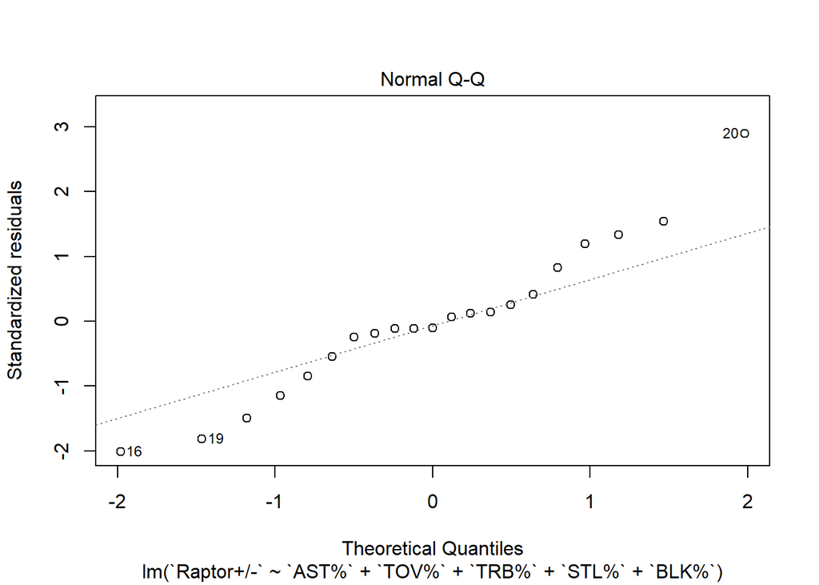

```r
plot(modatl,2)
```

```r
residuals(modatl)
```

```
##          1          2          3          4          5          6          7
##  2.5768515  0.4180528 -0.7685559  1.2947862 -0.3289232  3.3594720 -3.4837559
##          8          9         10         11         12         13         14
## -2.4800149  4.5522537  0.1933958 -0.2872549 -0.5364934 -1.6267803  0.3714639
##         15         16         17         18         19         20         21
##  2.5326589 -5.0326151 -0.2808048  0.7676998 -4.5159375  6.2273124 -2.9528111
```

```r
rstandard(modatl)
```

```
##           1           2           3           4           5           6
##  1.33950973  0.14489135 -0.24602062  0.41465927 -0.11428837  1.19823136
##           7           8           9          10          11          12
## -1.14499199 -0.84870236  1.53924097  0.06585096 -0.10132324 -0.18644424
##          13          14          15          16          17          18
## -0.54846774  0.11944506  0.83008621 -2.01387675 -0.11299598  0.25767404
##          19          20          21
## -1.81070032  2.89955274 -1.49354370
```

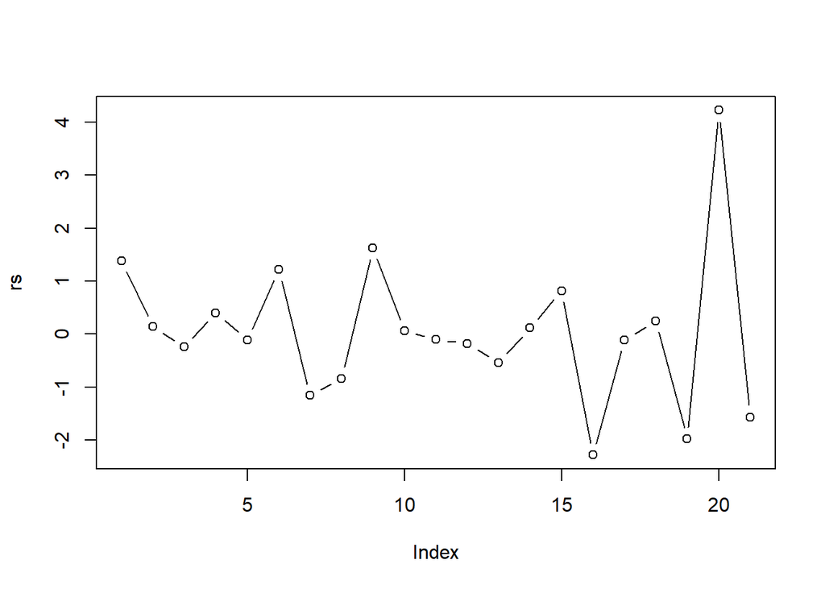

```r
#library(MASS)
rs <- studres(modatl)
plot(rs, type = 'b')
```

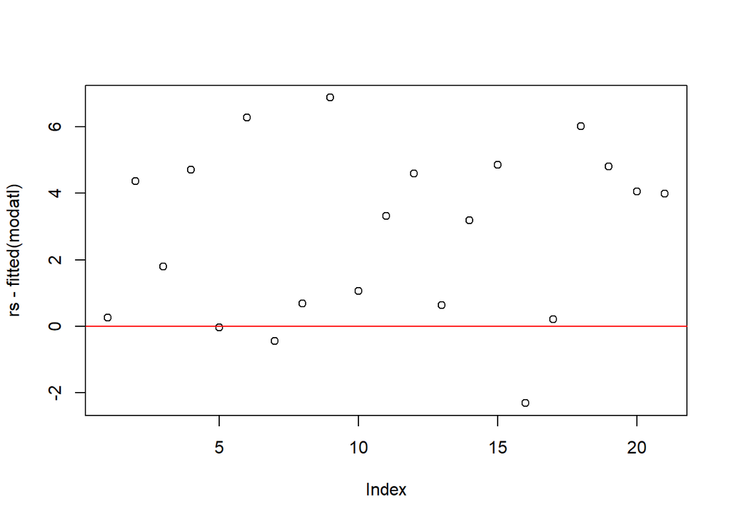

```r
plot(rs-fitted(modatl))
abline(h = 0, col = "red")
```

```r
bptest(modatl)
```

```
##
##  studentized Breusch-Pagan test
##
## data:  modatl
## BP = 12.906, df = 5, p-value = 0.02427
```

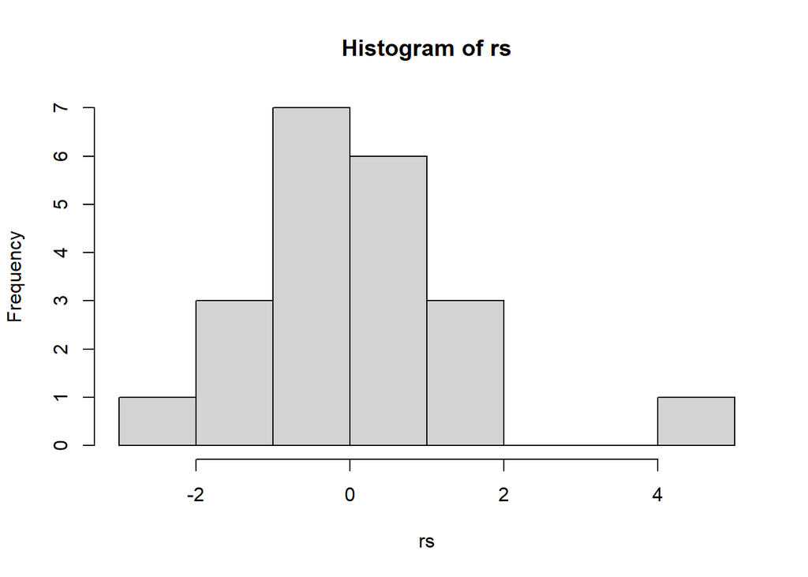

```r
hist(rs)
```

I decided to use just the variables that were significant to see if they would satisfy the assumptions. The updated model did satisfy all assumptions of normality, constant variance, and normality. However, one could note that other transformations could also work.

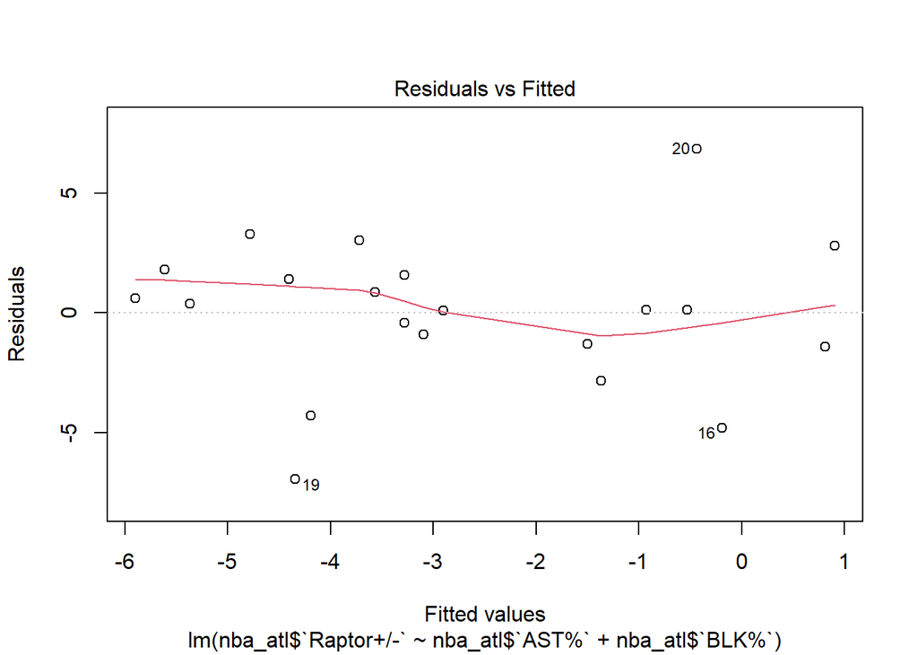

```r
# we will also check with the updated model first before we transform the model.

model <- lm(nba_atl$`Raptor+/-` ~ nba_atl$`AST%` + nba_atl$`BLK%`)

# looks a lot better the fitted vs residuals plot could look a little better
plot(model,1)
```

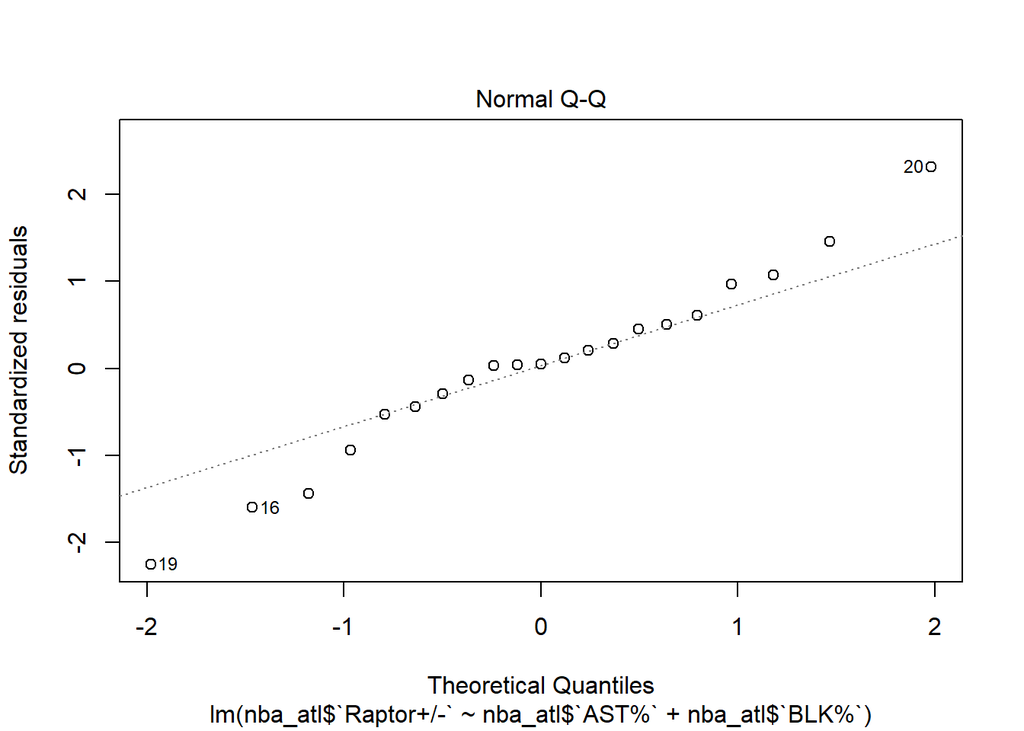

```r
plot(model,2)
```

```r
# Independance looks good
residuals(model)
```

```
##          1          2          3          4          5          6          7
##  2.7952988  1.8152555  0.1043012  1.4015288  0.1327343  1.5830619 -2.8330321
##          8          9         10         11         12         13         14
## -0.9070508  3.0191737  0.1311002 -0.4171823  0.5996515 -1.2980736  0.8681088
##         15         16         17         18         19         20         21
##  3.2807777 -4.8073041 -1.4140794  0.3690122 -6.9554155  6.8378813 -4.3057481
```

```r
rstandard(model)
```

```
##           1           2           3           4           5           6
##  1.45708572  0.60883628  0.03346864  0.45486093  0.04480629  0.50515869
##           7           8           9          10          11          12
## -0.94209719 -0.29136827  0.96721890  0.04336495 -0.13336076  0.20345781
##          13          14          15          16          17          18
## -0.43993505  0.28120766  1.07372893 -1.60168175 -0.53181891  0.12281678
##          19          20          21
## -2.25728058  2.32177585 -1.44035016
```

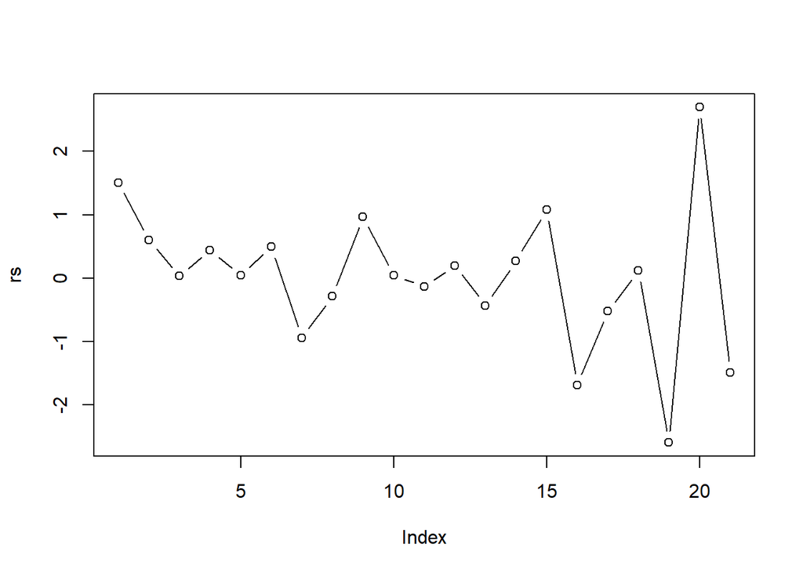

```r
#library(MASS)
rs <- studres(model)
plot(rs, type = 'b')
```

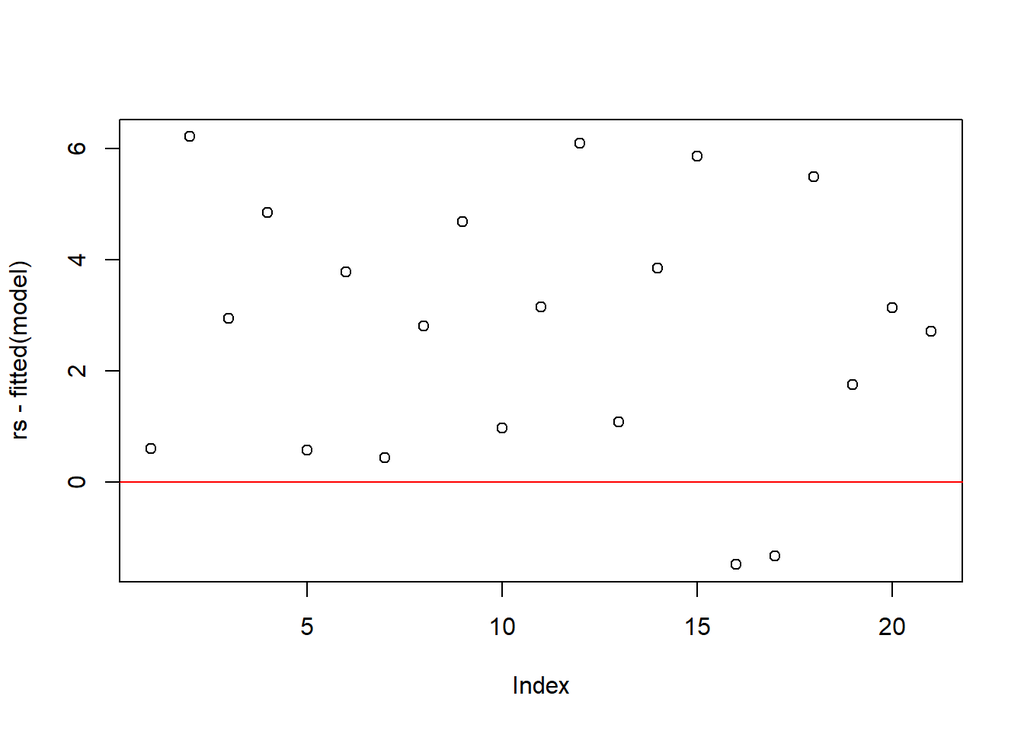

```r
#The fitted line could be changed and it would look fine, and the bptest looks good, probably h = 3 would work
plot(rs-fitted(model))
abline(h = 0, col = "red")
```

```r
bptest(model)
```

```
##
##  studentized Breusch-Pagan test
##
## data:  model
## BP = 0.39344, df = 2, p-value = 0.8214
```

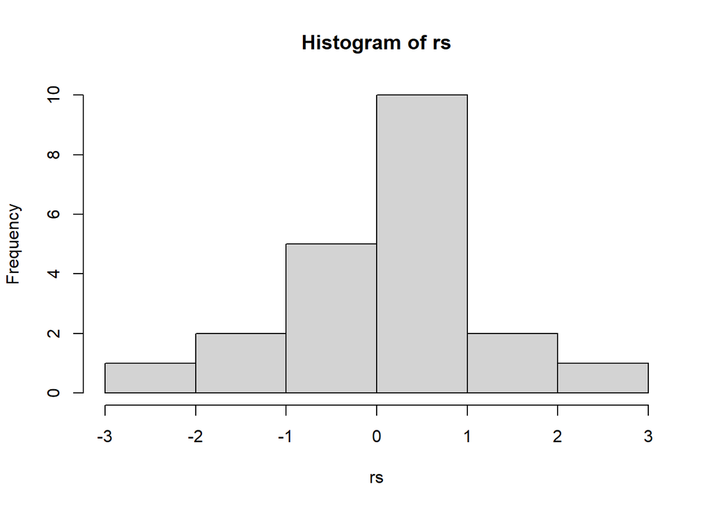

```r
hist(rs)
```

## Final Model

```r
# final model
model <- lm(nba_atl$`Raptor+/-` ~ nba_atl$`AST%` + nba_atl$`BLK%`)
summary(model)
```

```
##
## Call:
## lm(formula = nba_atl$`Raptor+/-` ~ nba_atl$`AST%` + nba_atl$`BLK%`)
##
## Residuals:
##     Min      1Q  Median      3Q     Max
## -6.9554 -1.2981  0.1327  1.5831  6.8379
##
## Coefficients:
##                Estimate Std. Error t value Pr(>|t|)
## (Intercept)    -8.19361    2.02508  -4.046 0.000758 ***
## nba_atl$`AST%`  0.18954    0.08598   2.204 0.040750 *
## nba_atl$`BLK%`  1.51716    0.55175   2.750 0.013180 *
## ---
## Signif. codes:  0 '***' 0.001 '**' 0.01 '*' 0.05 '.' 0.1 ' ' 1
##
## Residual standard error: 3.217 on 18 degrees of freedom
## Multiple R-squared:  0.3219, Adjusted R-squared:  0.2466
## F-statistic: 4.273 on 2 and 18 DF,  p-value: 0.0303
```

`nba_atl$`AST%` in this experiment is the Atlanta NBA team assist percentage for 2020. For the report this variable will be called AST.

H01: The coefficient of AST is equal to zero. Ha1: The coefficient of AST is not equal to zero.

The t-value for AST is 2.204, and the associated p-value is 0.04075. Since the p-value is less than the significance level of alpha = 0.05, we reject the null hypothesis and conclude that AST has a significant effect on the response variable.

nba_atl$`BLK%` in this experiment is the nba atlanta team blocking percentage for 2020, for this report the variable will be called BLK

H01: The coefficient of BLK is equal to zero. Ha1: The coefficient of BLK is not equal to zero.

The t-value for BLK is 2.750, and the associated p-value is 0.01318. Since the p-value is less than the significance level of alpha = 0.05, we reject the null hypothesis and conclude that BLK has a significant effect on the response variable.

# Cross Variance

```r
# Load the caret package
library(caret)
# Set the number of folds
num_folds <- 5

# Create a data partition for cross-validation
set.seed(123)  # for reproducibility
folds <- createFolds(nba$`Raptor+/-`, k = num_folds)

# Perform k-fold cross-validation
results <- lapply(folds, function(fold_indices) {
  train_data <- nba[-fold_indices, ]
  test_data <- nba[fold_indices, ]

  # Build and train your model on the training data
  model <- lm(nba$`Raptor+/-` ~ nba$`AST%` + nba$`BLK%`)

  # Make predictions on the test data
  predictions <- predict(model, newdata = test_data)

  # Calculate evaluation metrics (e.g., RMSE)
  rmse <- sqrt(mean((test_data$`Raptor+/-` - predictions)^2))

  return(rmse)
})

# Calculate the mean and standard deviation of the RMSE values
mean_rmse <- mean(unlist(results))
sd_rmse <- sd(unlist(results))

cat("Mean RMSE:", mean_rmse, "\n")
```

```
## Mean RMSE: 7.816871
```

```r
cat("Standard Deviation RMSE:", sd_rmse, "\n")
```

```
## Standard Deviation RMSE: 1.684576
```

```r
# Load the caret package
library(caret)


# Set the number of folds
num_folds <- 5

# Create a data partition for cross-validation
set.seed(123)  # for reproducibility
folds <- createFolds(nba$`Raptor+/-`, k = num_folds)

# Perform k-fold cross-validation
results <- lapply(folds, function(fold_indices) {
  train_data <- nba[-fold_indices, ]
  test_data <- nba[fold_indices, ]

  # Build and train your model on the training data
  model <- lm(nba$`Raptor+/-` ~ nba$`AST%` + nba$`BLK%`)

  # Make predictions on the test data
  predictions <- predict(model, newdata = test_data)

  # Calculate evaluation metrics (e.g., RMSE)
  rmse <- sqrt(mean((test_data$`Raptor+/-` - predictions)^2))

  return(rmse)
})

# Calculate the mean and standard deviation of the RMSE values
mean_rmse <- mean(unlist(results))
sd_rmse <- sd(unlist(results))

cat("Mean RMSE:", mean_rmse, "\n")
```

```
## Mean RMSE: 7.816871
```

```r
cat("Standard Deviation RMSE:", sd_rmse, "\n")
```

```
## Standard Deviation RMSE: 1.684576
```

# Conclusions

In conclusion, this study reveals the significant impact of blocking and assist percentages on Raptor scores for the Atlanta Hawks during the 2020 season. While this outcome aligns with the initial research question, the exploration was narrowed in scope to effectively navigate the extensive variables present in the original plan, which aimed to uncover the broader factors influencing Raptor scores across the entire NBA in 2020. A potential avenue for future investigation lies in expanding the analysis to encompass multiple seasons, offering deeper insights into the statistical markers that hold importance across different years or for distinct teams, as well as seeing how these factors impact a teams win loss rate.

Furthermore, investigating the interplay between various compositions of Raptor scores and their influence on team dynamics presents an intriguing prospect, considering the collaborative nature of basketball. Additionally, assessing the cascading effects of individual players’ performance dips on the overall team performance offers an intriguing perspective, although this endeavor may necessitate a more comprehensive dataset.